# The Dilemma of Holding on for One more Day: Oviductal egg retention as an energetically inexpensive mechanism to facilitate flexibility in reproductive phenology in gravid female Eastern Musk Turtles (*Sternotherus odoratus*)

Lyranda Thiem

```r
## Packages used for thesis analysis
knitr::opts_chunk$set(echo = TRUE)
packages_needed <- c("ggplot2", # graphics
                     "arm", # display() etc.
                     "ggfortify", # check model assumptions
                     "AICcmodavg",
                     "grid"
                     )
pk_to_install <- packages_needed [!( packages_needed %in% rownames(installed.packages())  )]
if(length(pk_to_install)>0 ){
  install.packages(pk_to_install,repos="http://cran.r-project.org")
}
#lapply(packages_needed, require, character.only = TRUE)
library(ggplot2)
library(arm)
library(ggfortify)
library(AICcmodavg)
library(grid)
library(tidyr)
library(dplyr)
library(knitr)
library(readr)
library(nlme)
library(lme4)
library(MuMIn)
library(readr)
library(rgdal)
library(ggplot2)
library(plyr)
library(arm)
library(MASS)
library(ggfortify)
library(AICcmodavg)
library(pspearman)
library(patchwork)
library(cowplot)
library(rmdformats)
```

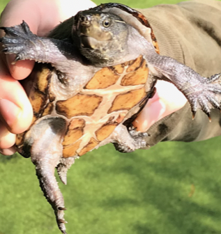

## Introduction

Life history suggest that individuals adopt optimized allocation strategies to partition available energy to the competing processes of maintenance, growth, and reproduction (Fisher 1930; Stearns 1976; Congdon and Tinkle 1982; Congdon et al. 1982). Reproductive output is constrained by both energy availability and by limitations of the environment (James and Whitford 1994).Thus, the energetic resources available for reproduction are finite and often tradeoffs exist between allocating energy towards mate acquisition (search time and courtship), number and size of offspring,and parental care (Congdon and Tinkle 1982; Congdon 1989). In reproducing individuals these tradeoffs can come at the cost of increased food requirements, increased chances of mortality, slowed growth, and reduced mobility (Coleman and Whittall 1988; Tallamy and Denno 1982; Shine 1980).

Theoretical models suggest that energetic costs of reproduction can be put in two major components: 1) reproductive effort, the total resources available to be allocated to reproductive activities (courtship, egg production) and 2) parental investment, how total reproductive effort is allocated towards individual offspring (Congdon et al. 1982). Parental investment can be further partitioned into embryogenesis, parental investment to embryo development, and care of offspring pre or post birth (Congdon 1989; Congdon and Gibbons 1985). Parental care has most often been studied in species where offspring survival is primarily influenced by maternal investment post-birth, as in many altricial mammals and birds (Broderick et al. 2003; Rafferty and Reina 2012). In oviparous reptiles, however, the investment of energy to parental care is primarily limited to eggs prior to oviposition (Packard and Packard 1988). Available energy is budgeted into mate acquisition and fertilization, vitellogenesis, egg production, oviductal egg retention (post-fertlization), and nest site selection (Owens 1980; Wallace et al. 2006; Congdon et al 1983; Congdon 1989).

Oviductal egg retention is a pivotal reproductive strategy for regulating timing in oviposition in many oviparous species (Renfree and Shaw 2000; Lopes et al 2004; Rafferty and Reina 2012). Egg retention allows reproductive flexibility by permitting females the ability to prolong oviposition until environmental conditions are suitable or until they can locate appropriate nesting sites. They may also use this strategy to time oviposition to increase the chances of synchronized hatching of clutches among conspecifics…predator dilution (Ewert 1979; Andrews 2004; Rafferty and Reina 2012). Squamates, crocodilians, and chelonians have the greatest diversity in prolonging egg retention (Ewert 1991). The oviductal egg retention period and developmental arrest for most squamates is about 25%- 40% of the total embryonic period, while in turtles this period can be more prolonged (Shine 1983; DeMarco 1993; Ewert 1985; Rafferty and Reina 2012; Andrews and Mathies 2000).

Most turtles exhibit oviductal egg retention (Ewert 1985), and once eggs have been fertilized, they develop a calcified shell and are retained in the oviduct. Embryonic development is then arrested, and eggs remain at the Gastrula stage and are retained for an extended period of time before oviposition (Ewert 1985; Rafferty and Reina 2012). Timing of oviductal egg retention differs among chelonians with some species retaining eggs for only a couple of days as observed in the leatherback sea turtle (<10 days) (Boulon et al. 1996; Girondot and Fretey 1996) to some species retaining eggs for a couple months (Pseudemydura umbrina 35-49 days) to others retaining eggs for half a year (Deirochelys reticularia 4-6.5 months) (Kutchling 1999; Buhlmann et al. 1995). Despite pronounced differences in duration of egg retention, no studies have yet focused on the energetic costs of this important life strategy, rather most studies have primarily focused on the total energetic costs of reproduction (Schwarzkopf and Shine 1992; Stewart 2013).

Thus, the aim of this study was to assess the energetic cost of oviductal egg retention in Eastern Musk Turtles (Sternotherus odoratus), a species that actively uses oviductal egg retention over the reproductive season (Risley 1933). Because the embryos undergo developmental arrest during the oviductal egg retention period, and because they are at a relatively early and metabolically quiescent gastrula stage, the energetic cost to females maintaining the embryos in the oviduct should be low.

**Hypothesis**: We hypothesize that oviductal egg retention is a beneficial reproductive strategy because it permits flexibility in timing of oviposition at a relatively low energetic cost to the mother. .

## Methods

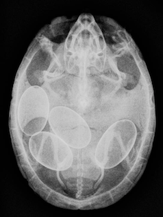

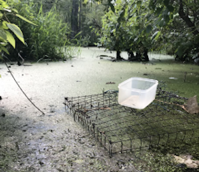

-Turtles were collected using Jones Traps

-Turtles were marked, weighed, and length of carapace and plastron was measured

-Females were x-rayed to determine whether they were gravid

-Turtles housed for three days prior to sampling and allowed to become digestively post absorptive

-Open-circuit respirometry was used to measure CO2 production for 48 hrs.

-Closed-circuit respirometry was used to measures O2 consumption 24 hrs after oviposition

-Conversion factors were used to convert metabolic measurements to joules/hr

-Metabolic rates were adjusted for mass and an ANCOVA with a pairwise analysis was run

-A Mixed model was run to determine signficant effects on female metabolic rate

-Repeated measures ANOVA with a post hoc was run to determine if gravid metabolic rates over time were signficant

### Site Description

Musk Turtles (Sternotherus odoratus) were captured from backwater sloughs along the Cumberland River, Cheatham County, Tennessee using Jones traps (Chandler et al. 2017).Traps were baited with canned tuna or sardines and placed in water deep enough to be mostly submerged, which allowed them to be left overnight and be checked the following day. Traps were left in the same location for a week prior to being moved. Traps were placed in murky/muddy water with duckweed covering.Trapping was conducted during the reproductive season from mid-May to September (Mitchell 1985, Ernst 1986, Ford and Moll 2004).

```r
packages<-c("ggsn","leaflet","mapdata","maptools","OpenStreetMap","rgdal","smoothr","sf","sp","tidyverse","tmap")
sapply(packages, require, character.only=T)
```

```
         ggsn       leaflet       mapdata      maptools OpenStreetMap         rgdal       smoothr            sf            sp
         TRUE          TRUE          TRUE          TRUE         FALSE          TRUE          TRUE          TRUE          TRUE
    tidyverse          tmap
         TRUE          TRUE
```

```r
state <- map_data("state")
county <- map_data("county")
swamp_point <- data.frame("x" = -87.079223, "y" = 36.285647)
```

```r
tn <- county %>%
  filter(region=="tennessee")

montco <- county %>%
  filter(region=="tennessee") %>%
  filter(subregion=="cheatham")
```

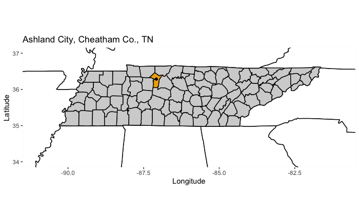

```r
map1<- ggplot() + geom_polygon(data = state, aes(x=long, y = lat, group = group),
                        fill = "white", color="black") +
           geom_polygon(data = tn, aes(x=long, y = lat, group = group),
                        fill = "lightgrey", color="black") +
           geom_polygon(data = montco, aes(x=long, y = lat, group = group),
                        fill = "darkgoldenrod2", color="black") +
           geom_point(data = swamp_point, aes(x=x,y=y), color=" black") +
  coord_fixed(xlim = c(-91, -81),  ylim = c(34, 37), ratio = 1.2) +
  xlab("Longitude") + ylab("Latitude") + ggtitle("Ashland City, Cheatham Co., TN")
map1
```

```r
sterno_traping <- read_csv("sterno_traping.csv")
```

```r
library(leaflet)
pal <- colorFactor(c( "brown", "darkgoldenrod2"), level = c("Absence", "Presence"))

map2<-leaflet(sterno_traping) %>% addProviderTiles(providers$Esri.WorldImagery) %>%
  addCircleMarkers(
    color = ~pal(Trap_Status),
    stroke = FALSE, fillOpacity = 0.5
  )%>%
   addLegend("bottomright", pal = pal, values = ~Trap_Status,
    title = "Turtle Trap Success",
    opacity = 1)
```

```
Assuming "longitude" and "latitude" are longitude and latitude, respectively
```

```r
map2
```

[interactive chart not shown]

### In Lab Methods

- All turtes were brought back to the lab to be measured, given a unique marking, and if female were x-rayed to determine reproductive state (Gravid vs Non-Gravid)
- Carbon dioxide production (VCO2) was measured for each individuals using flow through respirometry(Lighton 2008)
- Metabolic measurements were taken once for males and non-gravid females, while both gravid metabolic rate and post oviposition metabolic rates were determined for each gravid female
- Before intitiating a metabolic trial, turtles were fasted for 72 hours to allow food to clear the gut and ensure a post-absorptive digestive state
- Temperature was controlled at a constant 25 degrees celcius and a 12:12 photoperiod was used for the duration of a 48 hr testing cycle
- Carbon dioxide production was calculated at 3 sec intervals for the 48 h testing cycle, and the most level 15 min period from each 30 min sample was used to calculate the rate of gas exchange using the equations from Withers (1977) implemented in the program Lab Analyst (Warthog Systems)
- Metabolic rate for each individual was considered to be the mean of the three lowest 15 min measurements during 48 h test period
- Gravid females were measured over a weekly basis to obtain multiple measurements and were allowed to naturally oviposit eggs within a nest
- Clutch metabolic rates were measured 24 hours post-oviposition using closed circuit O2 respirometer

## Statisitcal Analyses

**Adjusting for Egg Metabolism**

Before we can run any tests we need to calculate energy produced during the respirometry run we need to convert our mL CO2/hr into joules/hr using conversion factors. The conversion factors were taken from Gessaman and Nagey 1988 and Reid et al 2009.

*Egg energy expenditure:* Conversion factor from Reid et al. 2009 VO2 converstion factor= 20.1 J/ml O2

After converting metabolic rates from mLCO2/h to joules/h we need to them subtract the metabolic rates of the whole clutch from the respected gravid female because we only want to examine the gravid females metabolic rate.

```r
full_data_metabolic_rates<- Sterno_All%>%
  mutate(Joules_hr_turtles= mL_CO2_hr_turtles*24.32)# we times the ml_CO2_hr_turtles by this conversion factor in order to joules Hr of energy
kable(full_data_metabolic_rates[1:10,],format = "pandoc", caption = 'Table 1. A knitr kable metabolic rates of Musk Turtle data.')
```

Table 1. A knitr kable metabolic rates of Musk Turtle data.

| Turtle_ID | Group | mL_CO2_hr_turtles | Turtle_Mass | ml_O2_min_eggs | whole_clutch_mass | ml_O2_hr_eggs | Joules_hr_turtles |
| --- | --- | --- | --- | --- | --- | --- | --- |
| ABL | Gravid Female | 4.708550 | 154 | 0.0002582 | 16.9 | 0.0154932 | 114.51194 |
| ACI | Gravid Female | 3.683805 | 111 | 0.0001496 | 14.3 | 0.0089736 | 89.59014 |
| ABU | Gravid Female | 5.171930 | 146 | 0.0002176 | 18.0 | 0.0130554 | 125.78134 |
| ABT | Gravid Female | 5.103395 | 145 | 0.0003070 | 12.4 | 0.0184200 | 124.11457 |
| ACT | Gravid Female | 4.757630 | 124 | 0.0002781 | 14.0 | 0.0166836 | 115.70556 |
| ACO | Gravid Female | 5.281002 | 196 | 0.0003208 | 19.8 | 0.0192456 | 128.43396 |
| AHT | Gravid Female | 3.886640 | 139 | 0.0003126 | 17.0 | 0.0187584 | 94.52308 |
| AHM | Gravid Female | 2.935713 | 100 | 0.0001420 | 11.1 | 0.0085224 | 71.39655 |
| AHL | Gravid Female | 4.439160 | 149 | 0.0003954 | 15.1 | 0.0237246 | 107.96037 |
| AH | Gravid Female | 4.672387 | 126 | 0.0002273 | 11.0 | 0.0136392 | 113.63244 |

```r
full_data_metabolic_rates_2<- full_data_metabolic_rates%>%
  mutate(Joules_hr_whole_clutch= ml_O2_hr_eggs*20.1)
kable(full_data_metabolic_rates_2[1:10,],format = "pandoc", caption = 'Table 1. A knitr kable metabolic rates of Musk Turtle data.')
```

Table 1. A knitr kable metabolic rates of Musk Turtle data.

| Turtle_ID | Group | mL_CO2_hr_turtles | Turtle_Mass | ml_O2_min_eggs | whole_clutch_mass | ml_O2_hr_eggs | Joules_hr_turtles | Joules_hr_whole_clutch |
| --- | --- | --- | --- | --- | --- | --- | --- | --- |
| ABL | Gravid Female | 4.708550 | 154 | 0.0002582 | 16.9 | 0.0154932 | 114.51194 | 0.3114133 |
| ACI | Gravid Female | 3.683805 | 111 | 0.0001496 | 14.3 | 0.0089736 | 89.59014 | 0.1803694 |
| ABU | Gravid Female | 5.171930 | 146 | 0.0002176 | 18.0 | 0.0130554 | 125.78134 | 0.2624135 |
| ABT | Gravid Female | 5.103395 | 145 | 0.0003070 | 12.4 | 0.0184200 | 124.11457 | 0.3702420 |
| ACT | Gravid Female | 4.757630 | 124 | 0.0002781 | 14.0 | 0.0166836 | 115.70556 | 0.3353404 |
| ACO | Gravid Female | 5.281002 | 196 | 0.0003208 | 19.8 | 0.0192456 | 128.43396 | 0.3868366 |
| AHT | Gravid Female | 3.886640 | 139 | 0.0003126 | 17.0 | 0.0187584 | 94.52308 | 0.3770438 |
| AHM | Gravid Female | 2.935713 | 100 | 0.0001420 | 11.1 | 0.0085224 | 71.39655 | 0.1713002 |
| AHL | Gravid Female | 4.439160 | 149 | 0.0003954 | 15.1 | 0.0237246 | 107.96037 | 0.4768645 |
| AH | Gravid Female | 4.672387 | 126 | 0.0002273 | 11.0 | 0.0136392 | 113.63244 | 0.2741479 |

```r
adjusting_metabolic_rates_gravid_females<- full_data_metabolic_rates_2%>%
  mutate(adj_energy_Joules_turtles=Joules_hr_turtles-Joules_hr_whole_clutch)
kable(adjusting_metabolic_rates_gravid_females[1:10,],format = "pandoc", caption = 'Table 1. Adjusted metabolic rates for Eastern Musk Turtles.')
```

Table 1. Adjusted metabolic rates for Eastern Musk Turtles.

| Turtle_ID | Group | mL_CO2_hr_turtles | Turtle_Mass | ml_O2_min_eggs | whole_clutch_mass | ml_O2_hr_eggs | Joules_hr_turtles | Joules_hr_whole_clutch | adj_energy_Joules_turtles |
| --- | --- | --- | --- | --- | --- | --- | --- | --- | --- |
| ABL | Gravid Female | 4.708550 | 154 | 0.0002582 | 16.9 | 0.0154932 | 114.51194 | 0.3114133 | 114.20052 |
| ACI | Gravid Female | 3.683805 | 111 | 0.0001496 | 14.3 | 0.0089736 | 89.59014 | 0.1803694 | 89.40977 |
| ABU | Gravid Female | 5.171930 | 146 | 0.0002176 | 18.0 | 0.0130554 | 125.78134 | 0.2624135 | 125.51892 |
| ABT | Gravid Female | 5.103395 | 145 | 0.0003070 | 12.4 | 0.0184200 | 124.11457 | 0.3702420 | 123.74432 |
| ACT | Gravid Female | 4.757630 | 124 | 0.0002781 | 14.0 | 0.0166836 | 115.70556 | 0.3353404 | 115.37022 |
| ACO | Gravid Female | 5.281002 | 196 | 0.0003208 | 19.8 | 0.0192456 | 128.43396 | 0.3868366 | 128.04712 |
| AHT | Gravid Female | 3.886640 | 139 | 0.0003126 | 17.0 | 0.0187584 | 94.52308 | 0.3770438 | 94.14604 |
| AHM | Gravid Female | 2.935713 | 100 | 0.0001420 | 11.1 | 0.0085224 | 71.39655 | 0.1713002 | 71.22525 |
| AHL | Gravid Female | 4.439160 | 149 | 0.0003954 | 15.1 | 0.0237246 | 107.96037 | 0.4768645 | 107.48351 |
| AH | Gravid Female | 4.672387 | 126 | 0.0002273 | 11.0 | 0.0136392 | 113.63244 | 0.2741479 | 113.35830 |

```r
Juveniles_Out <- adjusting_metabolic_rates_gravid_females[-c(14,15,16,17,18),] # taking the juveniles out because they have such different metabolic rates doesnt make sense to try to compare them to adults
```

**Data Description**

Below is a description of all the factor variables included within my data set.

**Turtle_ID**: 54 total individuals

**Group**: Gravid Females, Males, Non-Gravid Females

**mlCO2/hr turtles**: measured metabolic rates

**Turtle_Mass**: Individual turtle mass to the nearest gram

**mlO2/min eggs**: measured metabolic rates for whole clutch of eggs

**Whole clutch mass**: reported weigths(g) of the entire clutch for each gravid female

**mlO2/hr eggs**: measured metabolic rates for whole clutch of eggs

**Joules/hr turtles**: calculated joules per hour used my indivudal turtles using the conversion factor

**Joules/hr whole clutch**: calculated joules per hour used by the whole clutch from each gravid female

**adj_energy_joules_turtles**: subtracting the joules/hr for the clutch from each of the gravid females

### Group Metabolic Rates afyer adjusting for individual mass

```r
X.mean <- mean(Joules_energy_sterno$adj_mass_turtles) #mean of the covariate
model_SMR <- lm(adj_energy_Joules_turtles ~ adj_mass_turtles+ Group, data=Joules_energy_sterno)
pred <- predict(model_SMR)
plot_SMR2<- ggplot(data = cbind(Joules_energy_sterno, pred),
                 aes(adj_mass_turtles, adj_energy_Joules_turtles, lty=Group, pch=Group)) + geom_point(size=3.5) +
  geom_line(aes(y=pred), size=1.5)+
  geom_vline(xintercept = X.mean, alpha = 0.15)+
  xlab("Adjusted Mass (g)")+
  ylab("Metabolic Rate (Joules/hr)")+
  theme_classic(base_size = 15)
```

```r
gravid_plot<- plot_SMR+ scale_x_continuous(breaks = c(50, 60, 70, 80,90, 100, 110, 120,130,140,150,160,170,180,190))+scale_y_continuous(breaks=c(20, 30, 40,50,60,70,80,90,100,110,120,130,140,150,160,170,180))
```

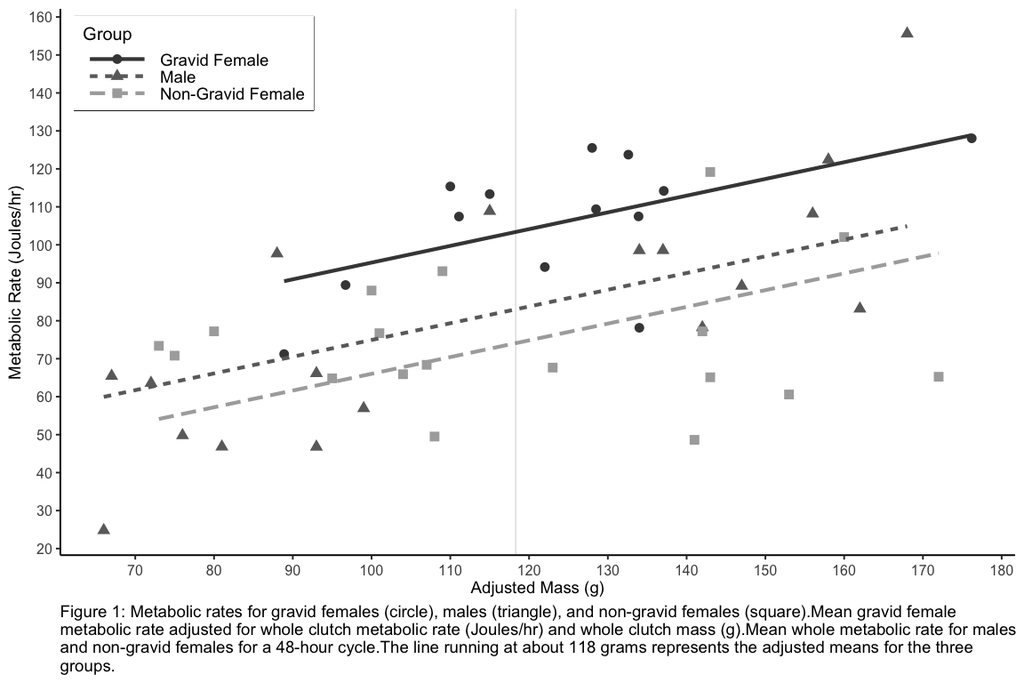

```r
gravid_plot+ guides(fill = guide_legend(keywidth = 1, keyheight = 1, cex=0.75),
    linetype=guide_legend(keywidth = 4, keyheight = 1),
    colour=guide_legend(keywidth = 4, keyheight = 1))+
   theme(legend.position = c(.14,.90),legend.box.background = element_rect(colour = "black"),
         axis.text.x = element_text(vjust=0.5, size = 12),
         axis.text.y = element_text(vjust = 0.5, size=12),
         axis.title.x = element_text(size=14),
         axis.title.y= element_text(size=14),
         legend.text = element_text(color = "black", size = 14))+
  labs(caption = "Figure 1: Metabolic rates for gravid females (circle), males (triangle), and non-gravid females (square).Mean gravid female
metabolic rate adjusted for whole clutch metabolic rate (Joules/hr) and whole clutch mass (g).Mean whole metabolic rate for males
and non-gravid females for a 48-hour cycle.The line running at about 118 grams represents the adjusted means for the three
groups.")+
  theme(plot.caption = element_text(hjust = 0, size=14))
```

All turtles have a positive correlation in metabolic rates (joules/hr) while accounting for the adjusted turtle mass (subtracting the gravid female’s clutch mass from her mass in order to get the actual mass of the female). From the graph it looks as though gravid females have a higher metabolic rate then do males and non-gravid females for the the reproductive season. We will run an ANCOVA with a pairwise test to determine if this is the case for these turtles.

Before running an ANCOVA and a pairwise test I ran the an autoplot to check for potential outliers. Here we see in the normal Q-Q plot that three values (16,15,36) could be potential outliers, however, they do not seem to deviate from the line too much so they may be okay.The first and third plot do not show any signficant pattern which is good.

### Checking Normality

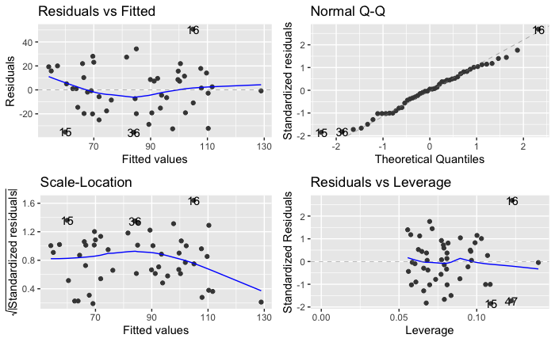

```r
autoplot(model_SMR)
```

### ANCOVA/Adjusted Means between groups

I ran an ANCOVA with adjusted means analysis in order to determine the average metabolic rates for each group while accounting for the covariate of body mass.

```r
smr<- lm(adj_energy_Joules_turtles~ adj_mass_turtles+Group, data=Joules_energy_sterno, digits=5)
anova(smr)
```

```
Analysis of Variance Table

Response: adj_energy_Joules_turtles
                 Df  Sum Sq Mean Sq F value    Pr(>F)
adj_mass_turtles  1  9959.3  9959.3 24.5875 1.056e-05 ***
Group             2  6550.1  3275.1  8.0855     0.001 **
Residuals        45 18227.4   405.1
---
Signif. codes:  0 ‘***’ 0.001 ‘**’ 0.01 ‘*’ 0.05 ‘.’ 0.1 ‘ ’ 1
```

```r
kable(anova(smr), format = "pandoc", caption ='Table 1. A summary kable displaying ANOVA summary table.')
```

Table 1. A summary kable displaying ANOVA summary table.

|  | Df | Sum Sq | Mean Sq | F value | Pr(>F) |
| --- | --- | --- | --- | --- | --- |
| adj_mass_turtles | 1 | 9959.259 | 9959.2592 | 24.587475 | 1.06e-05 |
| Group | 2 | 6550.128 | 3275.0639 | 8.085496 | 1.00e-03 |
| Residuals | 45 | 18227.437 | 405.0542 | NA | NA |

The ANCOVA results support the linear plot above in that group (gravid female, male, non-gravid female) is signficant in determing metabolic rates of the indivdual turtle.The adjusted mass also was signficantly correlated with metabolic rates of the turtles (joules/hr) with a p-value< 0.05.

### Emmeans

In order to adjust for the difference in mass of the three groups of turtles we need to use the package library(emmeans) to run our model.

```r
library(emmeans)
adj_turtles_1<-emmeans(smr, ~ adj_mass_turtles:Group, digits=3)
adj_turtles_1
```

```
 adj_mass_turtles Group             emmean   SE df lower.CL upper.CL
              118 Gravid Female      103.4 5.61 45     92.1    114.7
              118 Male                83.0 4.76 45     73.4     92.6
              118 Non-Gravid Female   74.1 4.74 45     64.5     83.6

Confidence level used: 0.95
```

```r
options(digits=3)
pairs(adj_turtles_1)
```

```
 contrast                                                          estimate   SE df t.ratio p.value
 118.30612244898,Gravid Female - 118.30612244898,Male                 20.38 7.39 45 2.760   0.0220
 118.30612244898,Gravid Female - 118.30612244898,Non-Gravid Female    29.29 7.35 45 3.990   0.0010
 118.30612244898,Male - 118.30612244898,Non-Gravid Female              8.91 6.72 45 1.330   0.3880

P value adjustment: tukey method for comparing a family of 3 estimates
```

After adjusting for the means of the metabolic rates we can now run a pairwise analysis to see if there were any differences among the group. Here we see that we get a signficant diffence between gravid females and males (p-value-0.022). A signficant difference is also seen between gravid females and non-gravid females (p-value=0.001). A nonsignficant difference is reported when looking at males and non-gravid females (p-value=0.388).